# 1.2-bmk-data-transforming

```python
# importing libraries
import pandas as pd
import numpy as np
import matplotlib.pyplot as plt
import seaborn as sns
```

```python
data = pd.read_csv('../data/interim/preprocessed_data.csv')
print(data.shape)
print(data.head())
print(data.columns)
```

```
(148, 31)
  Country Code     Country  Net Trade Status  Price Control in 2021  \
0          ALB    Albania                  1                      0
1          DZA    Algeria                  2                      1
2          AGO     Angola                  1                      1
3          ARG  Argentina                  1                      1
4          ARM    Armenia                  1                      0

   Subsidy in 2021  Tax Reduction in 2021  Price Control in 2022  \
0                1                      0                      1
1                2                      0                      1
2                2                      0                      1
3                0                      0                      1
4                0                      0                      0

   Subsidy in 2022  Tax Reduction in 2022  Price Control in 2023  ...  \
0                1                      0                      1  ...
1                2                      0                      1  ...
2                2                      0                      1  ...
3                0                      1                      1  ...
4                0                      0                      0  ...

   population data in 2022  population data in 2023  land area data in 2020  \
0                2777689.0                2745972.0                27400.00
1               45477389.0               46164219.0              2381740.00
2               35635029.0               36749906.0              1246700.00
3               45407904.0               45538401.0              2736690.00
4                2969200.0                2964300.0                28197.41

   land area data in 2021  land area data in 2022  land area data in 2023  \
0                27400.00                27400.00                27400.00
1              2381740.00              2381740.00              2381740.00
2              1246700.00              1246700.00              1246700.00
3              2736690.00              2736690.00              2736690.00
4                28197.09                28198.32                28199.44

   democracy index data in 2020  democracy index data in 2021  \
0                          6.08                          6.11
1                          3.77                          3.77
2                          3.66                          3.37
```

[output cut: 9 more lines]

```

[5 rows x 31 columns]
Index(['Country Code', 'Country', 'Net Trade Status', 'Price Control in 2021',
       'Subsidy in 2021', 'Tax Reduction in 2021', 'Price Control in 2022',
       'Subsidy in 2022', 'Tax Reduction in 2022', 'Price Control in 2023',
       'Subsidy in 2023', 'Tax Reduction in 2023', 'Price Control in 2024',
       'Subsidy in 2024', 'Tax Reduction in 2024', 'gdp data in 2020',
       'gdp data in 2021', 'gdp data in 2022', 'gdp data in 2023',
       'population data in 2020', 'population data in 2021',
       'population data in 2022', 'population data in 2023',
       'land area data in 2020', 'land area data in 2021',
       'land area data in 2022', 'land area data in 2023',
       'democracy index data in 2020', 'democracy index data in 2021',
       'democracy index data in 2022', 'democracy index data in 2023'],
      dtype='object')
```

Here is the data that we have assembled in the previous 2 notebooks. We have 148 rows, or countries, since we removed a few that were actually just territories. As for columns, we have net trade status, which tells us if a country is a net importer or exporter of oil. Then, all the other columns show the value of one of seven variables in one of four years. GDP data, population data, land area data, and democracy index data all give basic information about a country, and have data for the years from 2020 to 2023. This is because we are using basic information about a country to predict the policy they will implement in the next year, so we need basic data that is one year older than the policy data. Finally, we have 3 columns of data on oil subsidy policy across 4 years: Price control data, subsidy data, and tax reduction data. These are all policies, and the data indicates what a country's policy position was in that category in a given year. We have data on these from 2021 to 2024. Finally, we also have columns for country and country code. This is redundant, so we will drop the column for country.

Now, let's do some initial analysis of these variables.

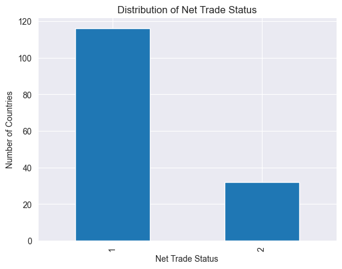

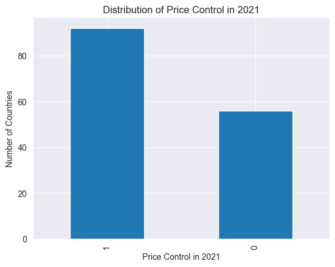

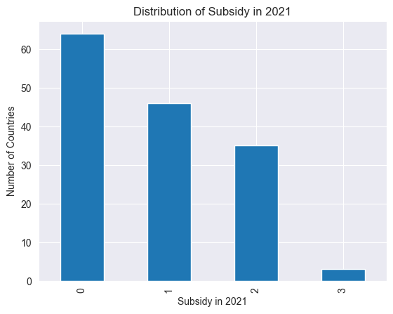

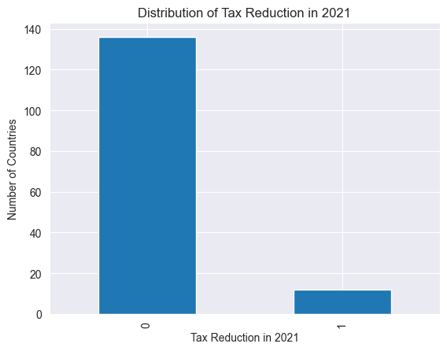

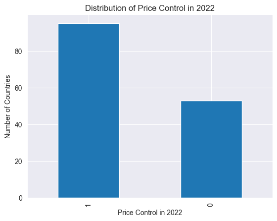

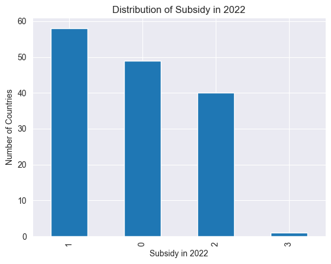

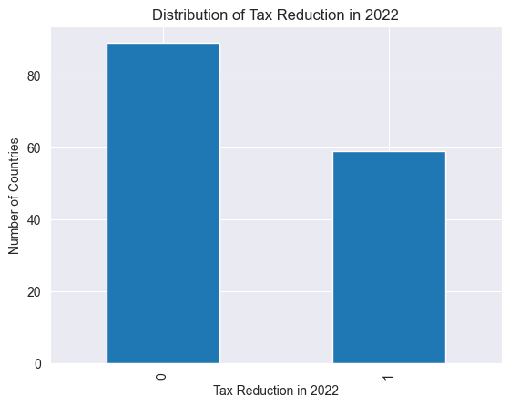

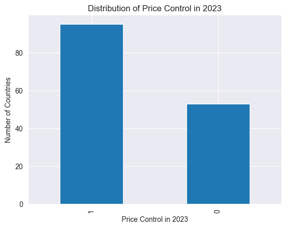

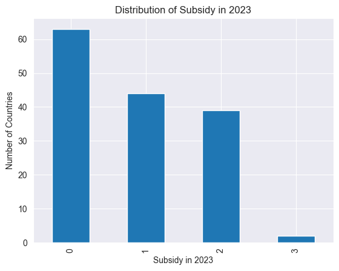

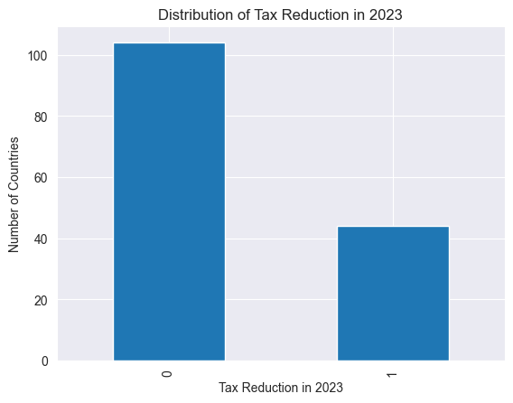

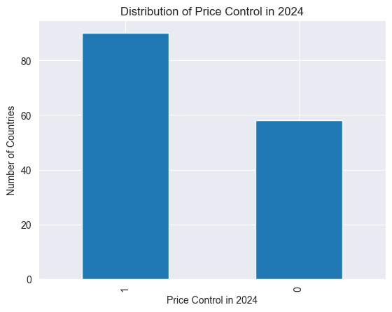

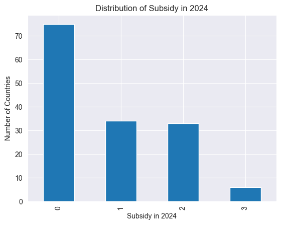

[1 more figures not shown]

```python
for column in ['Net Trade Status', 'Price Control in 2021',
       'Subsidy in 2021', 'Tax Reduction in 2021', 'Price Control in 2022',
       'Subsidy in 2022', 'Tax Reduction in 2022', 'Price Control in 2023',
       'Subsidy in 2023', 'Tax Reduction in 2023', 'Price Control in 2024',
       'Subsidy in 2024', 'Tax Reduction in 2024']:
    data[column].value_counts().plot(kind='bar')
    plt.xlabel(column)
    plt.ylabel('Number of Countries')
    plt.title('Distribution of ' + column)
    plt.show()
```

We will look at the subsidy data first. For each column, here is what each field means: Subsidy: 0 means no subsidies, 1 means some subsidy, 2 means there is "a recurring practice of freezing prices", and 3 means the situation is unclear. For most years, we can see that about half of countries have no subsidy, while the other countries are split about evenly between some subsidy and price freezing. A small number of them are unclear. With a practice of freezing prices included, these are qualitatively different from each other. Therefore, we will use pd.get_dummies to split them into separate columns. Tax reduction: 0 means fuel taxes were not reduced, 1 means they were, and 3 means unclear. This varies between years, but we can see a minority of countries have subsidies, and sometimes a tiny number are unclear. We will replace 3 with 0 in these columns so that unclear is marked as no reduction. With a small number of unclear values in the dataset, and most countries not reducing fuel taxes, this is the best way to make the data usable for the models we will be using. Price Control: this is 0 if prices are deregulated, and 1 if they are regulated. We can see that a majority of countries are regulated. With only 2 possible values, no pre-processing is necessary for this field. Finally, we can see that about a quarter of countries are net exporters of refined oil products, while the rest are net importers. As for the basic data on countries, we will make one change. We have data on the land area of each country, but we don't have a column for population density. Population density is a far more useful statistic, since it tells us more about what the conditions are in a country for people. which is more directly relevant for predicting policy decisions. Therefore, we will replace the column on land area with one on population density. After this change, we will do some analysis on those columns, and some bivariate analysis to see how columns relate to each other.

```python
data.drop(['Country'], axis=1, inplace=True)

for year in range(2020,2024,1):
    density_field_name = 'population density in ' + str(year)
    population_field_name = 'population data in ' + str(year)
    area_field_name = 'land area data in ' + str(year)
    data[density_field_name] = data[population_field_name] / data[area_field_name]
    data.drop([area_field_name], axis=1, inplace=True)
```

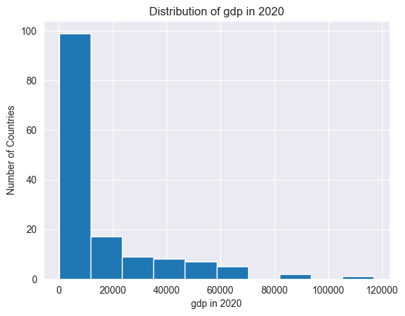

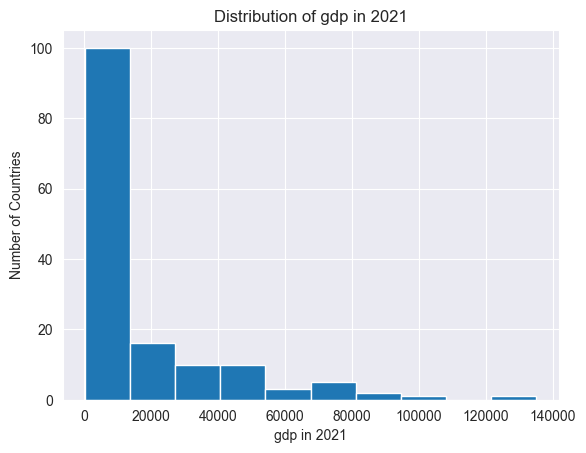

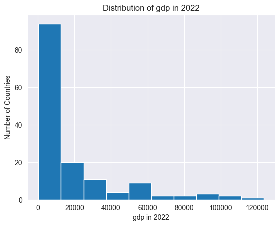

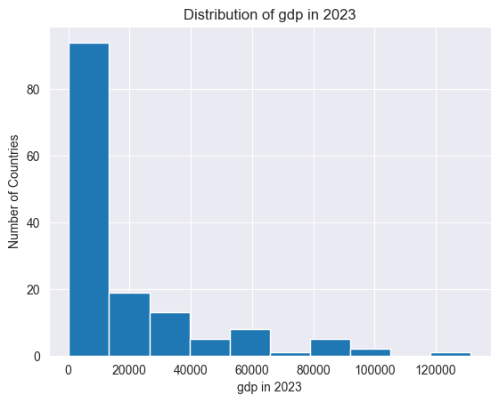

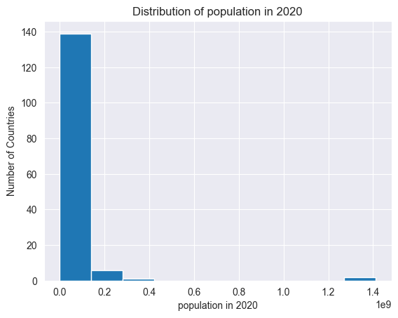

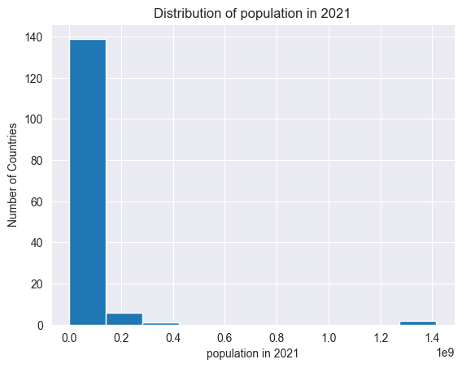

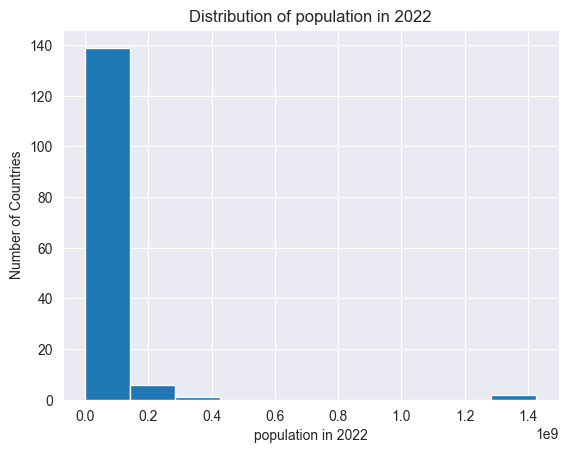

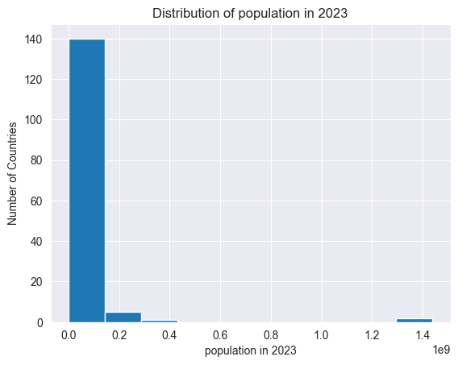

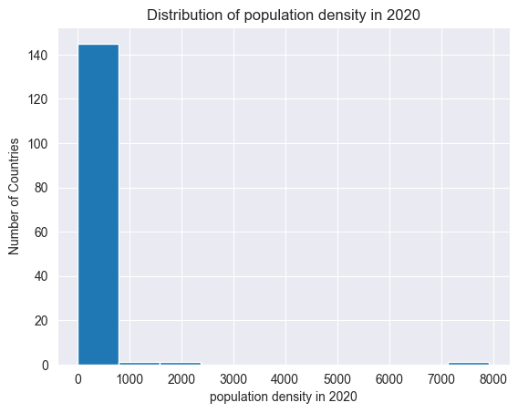

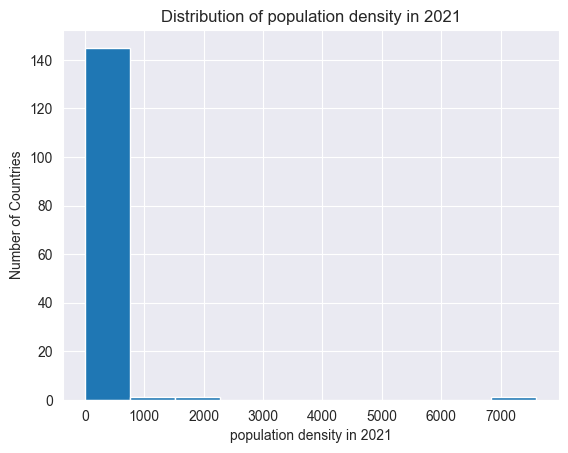

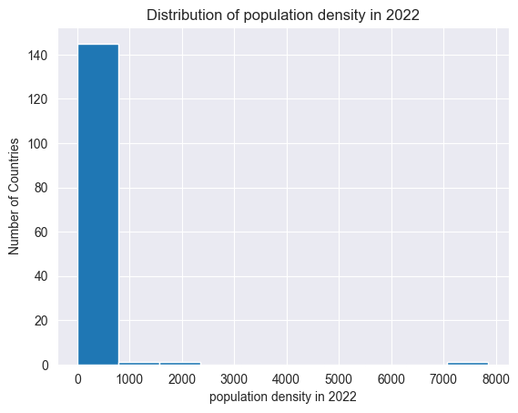

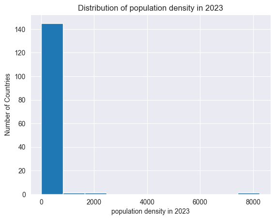

[4 more figures not shown]

```python
for column in ['gdp data in 2020',
       'gdp data in 2021', 'gdp data in 2022', 'gdp data in 2023',
       'population data in 2020', 'population data in 2021',
       'population data in 2022', 'population data in 2023',
       'population density in 2020', 'population density in 2021',
       'population density in 2022', 'population density in 2023',
       'democracy index data in 2020', 'democracy index data in 2021',
       'democracy index data in 2022', 'democracy index data in 2023']:
    plt.hist(data[column])
    display_name = column.replace('data ', '')
    plt.xlabel(display_name)
    plt.ylabel('Number of Countries')
    plt.title('Distribution of ' + display_name)
    plt.show()
```

Given the distribution of these variables, it makes sense to take the log of them to get a distribution that's closer to uniform. This will allow our models to better appreciate small differences in quantities on the left of these distributions.

```python
for year in range(2020,2024,1):
    density_field_name = 'population density in ' + str(year)
    population_field_name = 'population data in ' + str(year)
    gdp_field_name = 'gdp data in ' + str(year)
    for field in [density_field_name, population_field_name, gdp_field_name]:
        data['log_' + field] = np.log10(data[field])
        data.drop([field], axis=1, inplace=True)
```